# Guía3_Mara_Magalys_Eduardo

### **Grupo 7**

- Mara Alejandra Calderon Díaz
- Magalys del Carmen Camargo Hernandez
- Luis Eduardo Osorio Acevedo

# **Guía 3**

## **¿Cómo podemos controlar el creciente número de accidentes en Nueva York?**

## Introduccion

**Contexto empresarial.** La ciudad de Nueva York ha experimentado un aumento en el número de accidentes en las carreteras de la ciudad. Quieren saber si el número de accidentes ha aumentado en las últimas semanas. Para todos los accidentes reportados, han recopilado detalles para cada accidente y han estado manteniendo registros durante el último año y medio (desde enero de 2018 hasta agosto de 2019).

La ciudad te ha contratado para que construyas visualizaciones que les ayuden a identificar patrones en accidentes, lo que les ayudaría a tomar acciones preventivas para reducir la cantidad de accidentes en el futuro. Tienen ciertos parámetros como municipio, hora del día, motivo del accidente, etc. De los que se preocupan y de los que les gustaría obtener información específica.

**Problema comercial.** Su tarea es formatear los datos proporcionados y proporcionar visualizaciones que respondan las preguntas específicas que tiene el cliente, que se mencionan a continuación.

**Contexto analítico.** Se le proporciona un archivo CSV (accidente) que contiene detalles sobre cada accidente, como fecha, hora, ubicación del accidente, motivo del accidente, tipos de vehículos involucrados, recuento de lesiones y muertes, etc. El delimitador en el archivo CSV dado es `;` en lugar del predeterminado **`,`**.

Realizará las siguientes tareas con los datos:

1. Leer, transformar y preparar datos para su visualización
2. Realizar análisis y construir visualizaciones de los datos para identificar patrones en el conjunto de datos.

El cliente tiene un conjunto específico de preguntas a las que le gustaría obtener respuestas. Deberá proporcionar visualizaciones para acompañar estos:

1. ¿Cómo ha fluctuado el número de accidentes durante el último año y medio? ¿Han aumentado con el tiempo?
2. Para un día en particular, ¿durante qué horas es más probable que ocurran accidentes?
3. ¿Hay más accidentes entre semana que durante los fines de semana?
4. ¿Cuál es la proporción de recuento de accidentes por área por municipio? ¿Qué distritos tienen un número desproporcionadamente grande de accidentes para su tamaño?
5. Para cada municipio, ¿durante qué horas es más probable que ocurran accidentes?
6. ¿Cuáles son las 5 principales causas de accidentes en la ciudad?
7. ¿Qué tipos de vehículos están más involucrados en accidentes por municipio?
8. ¿Qué tipos de vehículos están más involucrados en las muertes?

## Overview de la data

Analizemos las columnas presentes en el data frame

Este conjunto de datos contiene información detallada sobre accidentes de tránsito registrados en la ciudad de Nueva York. A continuación, se presenta la descripción de cada columna:

- **BOROUGH**. Municipio donde ocurrió el accidente (ejemplo: Manhattan, Brooklyn, Queens, Bronx, Staten Island).
- **COLLISION_ID** Identificador único asignado a cada colisión para diferenciar los accidentes registrados.
- **CONTRIBUTING FACTOR VEHICLE** (1, 2, 3, 4, 5) Factores que contribuyeron a la ocurrencia del accidente, como exceso de velocidad, distracción del conductor, fallas mecánicas, malas condiciones climáticas, entre otros.

Se pueden registrar hasta cinco factores por accidente, cada uno correspondiente a un vehículo involucrado.

- **CROSS STREET NAME** Nombre de la calle transversal más cercana al lugar del accidente, útil para ubicar intersecciones peligrosas.
- **DATE** Fecha exacta en la que ocurrió el accidente en formato YYYY-MM-DD.
- **TIME** Hora del accidente en formato HH:MM AM/PM, permitiendo analizar patrones horarios en la siniestralidad.
- **LATITUDE y LONGITUDE**
- **NUMBER OF (CYCLISTS, MOTORISTS, PEDESTRIANS) INJURED** Número de personas heridas en el accidente, clasificadas en tres categorías: Ciclistas, Motociclistas - conductores de vehículos y Peatones.
- **NUMBER OF (CYCLISTS, MOTORISTS, PEDESTRIANS) DEATHS** Número de víctimas fatales en el accidente, categorizadas en: ciclistas, Motociclistas - conductores de vehículos y Peatones.
- **ON STREET NAME** Nombre de la calle donde ocurrió el accidente, información clave para el análisis de zonas de alto riesgo.
- **VEHICLE TYPE CODE (1, 2, 3, 4, 5)** Tipos de vehículos involucrados en el accidente, pudiendo haber hasta cinco vehículos registrados por accidente.

Sedán, SUV, Camión, Motocicleta, Autobús, Bicicleta, etc.

- **ZIP CODE** Código postal correspondiente a la ubicación del accidente, útil para agrupar eventos por áreas específicas dentro de la ciudad.

### **Limpieza del dataset**

Para asegurar que los datos sean consistentes y puedan ser analizados correctamente, realizaremos la imputación de los valores faltantes en las columnas que presentan datos nulos. A continuación, se detallan los pasos que debes seguir para limpiar el conjunto de datos.

- **Paso 1: Identificar los valores faltantes**
- **Paso 2: Decidir el método de imputación**

Dado el análisis de valores nulos, se aplicarán diferentes estrategias de imputación según el tipo de dato. Por ejemplo: para la columna ZIP CODE, se imputará con el código postal más frecuente (moda) dentro de cada municipio registrado en BOROUGH. En el caso de las coordenadas LATITUDE y LONGITUDE, se reemplazarán los valores faltantes con la media de las coordenadas dentro de cada municipio. La columna ON STREET NAME será rellenada con "UNKNOWN" en caso de estar vacía. Para los factores que contribuyeron al accidente (CONTRIBUTING FACTOR VEHICLE X), los valores nulos serán sustituidos por "Unspecified". Finalmente, en las columnas de VEHICLE TYPE CODE X, los valores ausentes se reemplazarán con "Unknown" para asegurar la integridad del análisis.

```python
# Importar librerias a usar
import pandas as pd
import numpy as np
import matplotlib.pyplot as plt
import seaborn as sns
# Convertir información en un data set de pandas
df=pd.read_csv('/content/accidents-1.csv',sep=';')
# Visualizar primeros 5 registros
df.head()
```

|  | DATE | TIME | BOROUGH | ZIP CODE | LATITUDE | LONGITUDE | ON STREET NAME | NUMBER OF PEDESTRIANS INJURED | NUMBER OF PEDESTRIANS KILLED | NUMBER OF CYCLIST INJURED | ... | CONTRIBUTING FACTOR VEHICLE 2 | CONTRIBUTING FACTOR VEHICLE 3 | CONTRIBUTING FACTOR VEHICLE 4 | CONTRIBUTING FACTOR VEHICLE 5 | COLLISION_ID | VEHICLE TYPE CODE 1 | VEHICLE TYPE CODE 2 | VEHICLE TYPE CODE 3 | VEHICLE TYPE CODE 4 | VEHICLE TYPE CODE 5 |
| --- | --- | --- | --- | --- | --- | --- | --- | --- | --- | --- | --- | --- | --- | --- | --- | --- | --- | --- | --- | --- | --- |
| 0 | 09/26/2018 | 12:12 | BRONX | 10454.0 | 40.808987 | -73.911316 | NaN | 0 | 0 | 0 | ... | NaN | NaN | NaN | NaN | 3988123 | Sedan | NaN | NaN | NaN | NaN |
| 1 | 09/25/2018 | 16:30 | BROOKLYN | 11236.0 | 40.636005 | -73.912510 | FLATLANDS AVENUE | 1 | 0 | 0 | ... | NaN | NaN | NaN | NaN | 3987962 | Sedan | NaN | NaN | NaN | NaN |
| 2 | 08/22/2019 | 19:30 | QUEENS | 11101.0 | 40.755490 | -73.939530 | NaN | 0 | 0 | 0 | ... | NaN | NaN | NaN | NaN | 4193132 | Sedan | NaN | NaN | NaN | NaN |
| 3 | 09/23/2018 | 13:10 | QUEENS | 11367.0 | NaN | NaN | MAIN STREET | 0 | 0 | 1 | ... | Unspecified | NaN | NaN | NaN | 3985962 | Bike | Station Wagon/Sport Utility Vehicle | NaN | NaN | NaN |
| 4 | 08/20/2019 | 22:40 | BRONX | 10468.0 | 40.868336 | -73.901270 | NaN | 0 | 0 | 0 | ... | Unspecified | NaN | NaN | NaN | 4192111 | Sedan | Sedan | NaN | NaN | NaN |

5 rows × 24 columns

```python
#Información general del dataframe e identificación de valores nulos
df.info()
```

```
<class 'pandas.core.frame.DataFrame'>
RangeIndex: 238522 entries, 0 to 238521
Data columns (total 24 columns):
 #   Column                         Non-Null Count   Dtype
---  ------                         --------------   -----
 0   DATE                           238522 non-null  object
 1   TIME                           238522 non-null  object
 2   BOROUGH                        238522 non-null  object
 3   ZIP CODE                       238452 non-null  float64
 4   LATITUDE                       231544 non-null  float64
 5   LONGITUDE                      231544 non-null  float64
 6   ON STREET NAME                 153918 non-null  object
 7   NUMBER OF PEDESTRIANS INJURED  238522 non-null  int64
 8   NUMBER OF PEDESTRIANS KILLED   238522 non-null  int64
 9   NUMBER OF CYCLIST INJURED      238522 non-null  int64
```

[output cut: 16 more lines]

```python
# Identificacion valores faltantes
print("los valores faltantes en cada columa")
print(df.isnull().sum())

print("los valores faltantes en cada fila")
print(df.isnull().any(axis=1).sum())
```

```
los valores faltantes en cada columa
DATE                                  0
TIME                                  0
BOROUGH                               0
ZIP CODE                             70
LATITUDE                           6978
LONGITUDE                          6978
ON STREET NAME                    84604
NUMBER OF PEDESTRIANS INJURED         0
NUMBER OF PEDESTRIANS KILLED          0
NUMBER OF CYCLIST INJURED             0
NUMBER OF CYCLIST KILLED              0
NUMBER OF MOTORIST INJURED            0
NUMBER OF MOTORIST KILLED             0
CONTRIBUTING FACTOR VEHICLE 1       884
CONTRIBUTING FACTOR VEHICLE 2     40008
CONTRIBUTING FACTOR VEHICLE 3    225450
CONTRIBUTING FACTOR VEHICLE 4    235666
CONTRIBUTING FACTOR VEHICLE 5    237730
COLLISION_ID                          0
VEHICLE TYPE CODE 1                1721
VEHICLE TYPE CODE 2               55590
VEHICLE TYPE CODE 3              226221
VEHICLE TYPE CODE 4              235806
VEHICLE TYPE CODE 5              237769
dtype: int64
los valores faltantes en cada fila
238070
```

```python
#Imputacion de campo ZIP CODE con moda BOROUGH
df['ZIP CODE']= df['ZIP CODE'].fillna(df.groupby('BOROUGH')['ZIP CODE'].transform(lambda x: x.mode().iloc[0]))
```

```python
# Imputación con el promedio columna LATITUDE
df['LATITUDE'] = df['LATITUDE'].fillna(df.groupby('BOROUGH')['LATITUDE'].transform(lambda x: x.mean()))
# Imputación con el promedio columna LONGITUDE
df['LONGITUDE'] = df['LONGITUDE'].fillna(df.groupby('BOROUGH')['LONGITUDE'].transform(lambda x: x.mean()))
```

```python
# Imputación con el constante columna ON STREET NAME
df['ON STREET NAME'] = df['ON STREET NAME'].fillna('UNKNOWN')
```

```python
# Imputación con el constante columna CONTRIBUTING FACTOR VEHICLE X
listafactores=['CONTRIBUTING FACTOR VEHICLE 1','CONTRIBUTING FACTOR VEHICLE 2','CONTRIBUTING FACTOR VEHICLE 3','CONTRIBUTING FACTOR VEHICLE 4','CONTRIBUTING FACTOR VEHICLE 5']
for i in listafactores:
  df[i] = df[i].fillna('Unspecified')
```

```python
# Imputación con el constante columna VEHICLE TYPE CODE X
listavehiculos=['VEHICLE TYPE CODE 1','VEHICLE TYPE CODE 2','VEHICLE TYPE CODE 3','VEHICLE TYPE CODE 4','VEHICLE TYPE CODE 5']
for i in listavehiculos:
  df[i] = df[i].fillna('Unknown')
```

```python
#Validacion valores nulos
print("los valores faltantes en cada columa")
print(df.isnull().sum())
```

```
los valores faltantes en cada columa
DATE                             0
TIME                             0
BOROUGH                          0
ZIP CODE                         0
LATITUDE                         0
LONGITUDE                        0
ON STREET NAME                   0
NUMBER OF PEDESTRIANS INJURED    0
NUMBER OF PEDESTRIANS KILLED     0
NUMBER OF CYCLIST INJURED        0
NUMBER OF CYCLIST KILLED         0
NUMBER OF MOTORIST INJURED       0
NUMBER OF MOTORIST KILLED        0
CONTRIBUTING FACTOR VEHICLE 1    0
CONTRIBUTING FACTOR VEHICLE 2    0
CONTRIBUTING FACTOR VEHICLE 3    0
CONTRIBUTING FACTOR VEHICLE 4    0
CONTRIBUTING FACTOR VEHICLE 5    0
COLLISION_ID                     0
VEHICLE TYPE CODE 1              0
VEHICLE TYPE CODE 2              0
VEHICLE TYPE CODE 3              0
VEHICLE TYPE CODE 4              0
VEHICLE TYPE CODE 5              0
dtype: int64
```

### Ejercicio 1

Desde 2014, la ciudad de Nueva York ha estado implementando el programa de seguridad vial Vision Zero, cuyo objetivo es reducir a cero el número de muertes por accidentes de tránsito para el año 2024. Como parte de esta iniciativa, se han implementado y mejorado diversas estrategias para aumentar la seguridad en las calles.

A continuación, se presentan algunas de las medidas adoptadas en el plan:

- Detección automatizada de peatones para mejorar la seguridad en los cruces.
- Auditorías de seguridad vial en zonas con alta incidencia de accidentes.
- Expansión de la red de carriles para bicicletas para reducir la exposición de ciclistas a incidentes con vehículos.
- Programas de educación y sensibilización para fomentar el respeto a las normas de tránsito.
- Construcción de islas de refugio peatonal para mejorar la seguridad en calles de alto tráfico.
- Implementación de reductores de velocidad inteligentes, como topes y amortiguadores, basados en el análisis de datos.

**Pregunta: ¿Cuáles de estas iniciativas podrían beneficiarse directamente del análisis de los datos disponibles sobre accidentes? Marque todas las opciones que considere aplicables.**

Instrucciones: Para marcar una opción, agregue una "[x]" en la casilla correspondiente.

### **Sigamos adelante y respondamos a cada una de las preguntas del cliente.**

### Ejercicio 2:

Agrupe los datos disponibles mensualmente y genere un line plot de accidentes a lo largo del tiempo. ¿Ha aumentado el número de accidentes durante el último año y medio?

**Sugerencia**: Puede encontrar útiles las funciones de pandas `to_datetime ()` y `dt.to_period ()`.

```python
df_tim = df.copy()
# Convertir la columna DATE en formato de fecha
df_tim['DATE'] = pd.to_datetime(df_tim['DATE'], format="%m/%d/%Y")
# Convertir columna en perios mensuales
df_tim['DATE'] = df_tim['DATE'].dt.to_period('M')
```

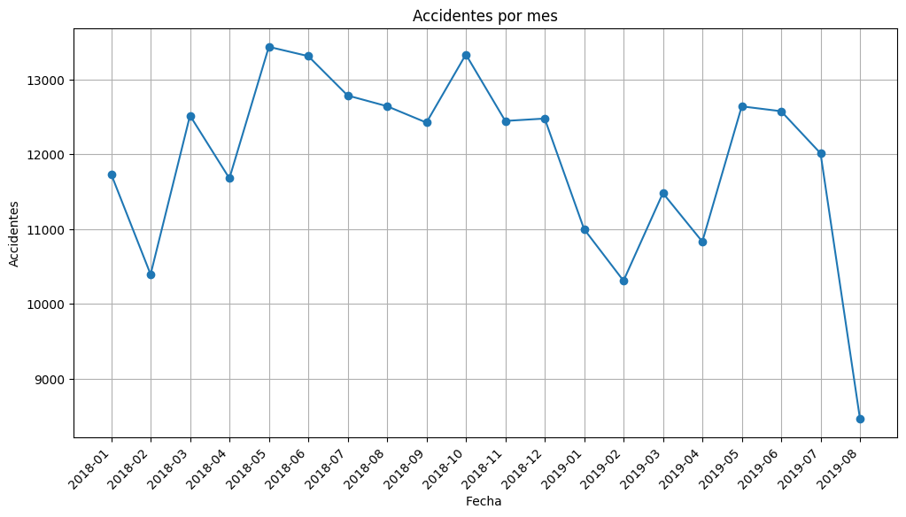

```python
# Graficar linea de tiempo
fig, ax = plt.subplots(figsize=(12, 6))

ax.plot(df_tim['DATE'].value_counts().sort_index().index.astype(str), df_tim['DATE'].value_counts().sort_index().values, marker='o')
# Rotar etiquetas para evitar superposiciones
plt.xticks(rotation=45, ha='right')

plt.title('Accidentes por mes')
plt.xlabel('Fecha ')
plt.ylabel('Accidentes')
plt.grid(True)
plt.show()
```

El gráfico de líneas que trazamos muestra claramente que no hay una tendencia alcista obvia en los accidentes a lo largo del tiempo.

De la gráfica anterior, ¿qué meses parecen tener el menor número de accidentes? ¿Cuáles crees que son las razones detrás de esto?

**RESPUESTA:** Los meses que muestran un numero menor de accidentes son: febrero para los años 2018 y 2019, y enero y abril para el año 2019, esto puede deberse a que la gente sale menos por la bajas temperaturas de la ciudad, tambien por que acaban de salir de viaje por las fiestas o que no tiene la sificiente liquidez. No obstante, en el ultimo mes registrado muestra un número muy bajo, pero esto se puede deber a que no se tomaron datos del mes completo.

### Ejercicio 3:

¿Cómo varía el número de accidentes a lo largo de un solo día? Cree una nueva columna `HOUR` basada en los datos de la columna `TIME`, luego trace un gráfico de barras de la distribución por hora a lo largo del día.

**Sugerencia:** Puede encontrar útil la función `dt.hour`.

```python
# Convertir la columna TIME a formato de hora y extraer la hora
df_tim['TIME'] = pd.to_datetime(df_tim['TIME'], format='%H:%M')
df_tim['HOUR'] = df_tim['TIME'].dt.hour
```

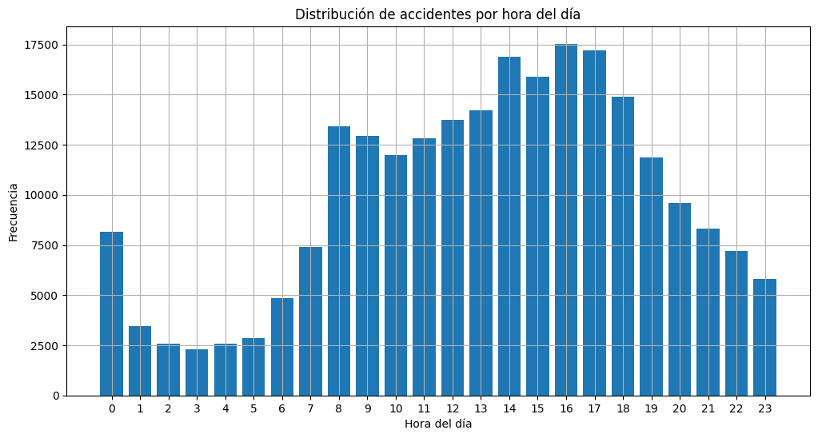

```python
# Generar grafico de barras
fig, ax = plt.subplots(figsize=(12, 6))
ax.bar(df_tim['HOUR'].value_counts().sort_index().index.astype(str), df_tim['HOUR'].value_counts().sort_index().values)

# Generar textos en el grafico
plt.title('Distribución de accidentes por hora del día')
plt.xlabel('Hora del día')
plt.ylabel('Frecuencia')
plt.grid(True)
```

En la pregunta anterior hemos agregado el número de accidentes por hora sin tener en cuenta la fecha y el lugar en que ocurrieron. ¿Qué crítica le daría a este enfoque?

**RESPUESTAS:** El gráfico de barras muestra la distribución de accidentes por hora del día, evidenciando picos entre las 7-9 AM y las 3-6 PM, lo que coincide con las horas pico de tránsito, cuando las personas se desplazan hacia y desde el trabajo o la escuela. En contraste, se observa una disminución significativa entre las 2-5 AM, probablemente debido a un menor volumen de tráfico. Además, hay un ligero aumento alrededor de la medianoche, posiblemente relacionado con conductores cansados o bajo efectos del alcohol.

### Ejercicio 4:

¿Cómo varía el número de accidentes en una sola semana? Trace un gráfico de barras basado en el recuento de accidentes por día de la semana.

**Sugerencia:** Puede encontrar útil la función `dt.weekday`.

```python
# Generar copia del dataframe
df_tim_1 = df.copy()
# Cambiar fecha a días de la semana
df_tim_1['DATE']= pd.to_datetime(df_tim_1['DATE'], format="%m/%d/%Y")
df_tim_1['DIA'] = df_tim_1['DATE'].dt.weekday
```

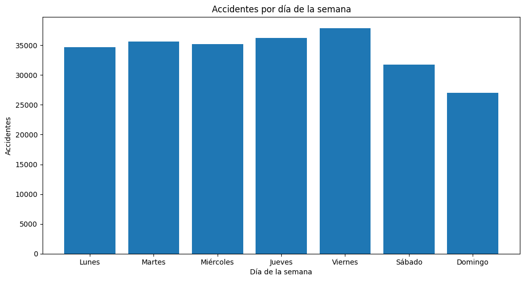

```python
# Generar liencio para la grafica
fig, ax = plt.subplots(figsize=(12, 6))

# Generar etiquetas para el eje X
dias_semana = ['Lunes', 'Martes', 'Miércoles', 'Jueves', 'Viernes', 'Sábado', 'Domingo']

# Grafica de barras por dia de la semana
ax.bar(dias_semana, df_tim_1['DIA'].value_counts().sort_index().values)

# Etiquetar ejes y titulo
plt.title('Accidentes por día de la semana')
plt.xlabel('Día de la semana')
plt.ylabel('Accidentes')
plt.show()
```

**RESPUESTA**: El número de accidentes varía a lo largo de la semana, mostrando una mayor incidencia de lunes a viernes, con un pico los viernes, lo que podría deberse al aumento del tráfico al final de la jornada laboral y actividades recreativas nocturnas. Durante el fin de semana, los accidentes disminuyen, siendo sábado y especialmente domingo los días con menor cantidad de incidentes. Esto podría estar relacionado con una reducción en los desplazamientos laborales y escolares

### Ejercicio 5:

Trace una gráfica de barras del número total de accidentes en cada municipio, así como uno de los accidentes por milla cuadrada por municipio. ¿Qué puedes concluir?

**Sugerencia:** Es posible que desee actualizar algunas de las claves en el diccionario del municipio para que coincidan con los nombres en el marco de datos.

[figure not shown]

```python
# Grafica de barras por dia de la semana
fig, ax = plt.subplots(figsize=(12, 6))

ax.bar(df.BOROUGH.unique(), df['BOROUGH'].value_counts().sort_index().values)

# Rotar etiquetas para evitar superposiciones
plt.xticks(rotation=45, ha='right')

# Etiquetar ejes y titulo
plt.title('Accidentes por Municipio')
plt.xlabel('Municipio')
plt.ylabel('Accidentes')
plt.show()
```

```python
area = {
"BRONX": 42.2,
"BROOKLYN": 69.4,
"MANHATTAN": 22.7,
"QUEENS": 108.7,
"STATEN ISLAND": 57.5
}
```

```python
df_cont=df['BOROUGH'].value_counts()
df_cont = df_cont.to_frame()
df_cont['Area'] = pd.Series(area).values
df_cont['BOROUGH'] = df_cont.index
df_cont['Accidentes por milla'] = df_cont.index.map(area) / df_cont['count']
print(df_cont)
```

```
               count   Area        BOROUGH  Accidentes por milla
BOROUGH
BROOKLYN       76253   42.2       BROOKLYN              0.000910
QUEENS         67120   69.4         QUEENS              0.001619
MANHATTAN      48749   22.7      MANHATTAN              0.000466
BRONX          37709  108.7          BRONX              0.001119
STATEN ISLAND   8691   57.5  STATEN ISLAND              0.006616
```

[figure not shown]

```python
# Grafica de barras por dia de la semana
fig, ax = plt.subplots(figsize=(12, 6))

ax.bar(df_cont['BOROUGH'], df_cont['Accidentes por milla'])

# Rotar etiquetas para evitar superposiciones
plt.xticks(rotation=45, ha='right')

# Etiquetar ejes y titulo
plt.title('Accidentes por milla cuadrada por municipio')
plt.xlabel('Municipio')
plt.ylabel('Accidentes por milla cuadrada')
plt.show()
```

Podemos ver que Brooklyn y Queens tienen un número muy alto de accidentes en relación con los otros tres condados. Pero, ¿qué tal por milla cuadrada?

### Ejercicio 6:

¿Qué horas tienen más accidentes en cada municipio? Trace un gráfico de barras para cada municipio que muestre el número de accidentes por cada hora del día.

**Sugerencia:** Puede usar `sns.FacetGrid` para crear una cuadrícula de parcelas con los datos por hora de cada municipio.

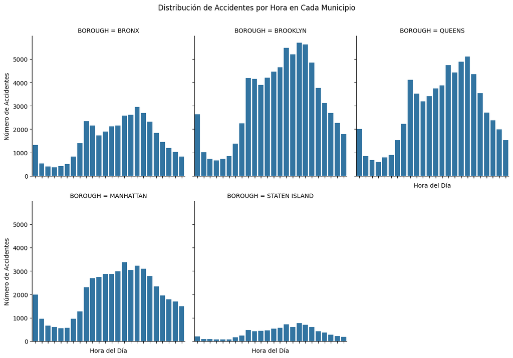

```python
# Crear cuadricula de graficos con FacetGrid
g = sns.FacetGrid(df_tim, col="BOROUGH", col_wrap=3, height=4)

# Crear grafico
g.map(sns.countplot, 'HOUR', order=range(24))

# Ajustar títulos y etiquetas
g.set_axis_labels("Hora del Día", "Número de Accidentes")
g.set_xticklabels(rotation=45)
plt.suptitle("Distribución de Accidentes por Hora en Cada Municipio", fontsize=12, y=1.05)

plt.show()
```

**¿Es mayor el número de accidentes en diferentes momentos en diferentes distritos? ¿Deberíamos concentrarnos en diferentes momentos para cada municipio?**

**RESPUESTA:** Se evidencia que de 5 municipios 4 presentan mayor numero de accidentes durante las 4pm a 5 pm. Si deberiamos concentrarnos en esas ciertas hora, puede darse por la hora de salida de muchos trabajadores.

El gráfico muestra que los accidentes varían según el municipio. Brooklyn y Queens tienen picos entre 3-5 PM, mientras que Manhattan registra un aumento desde las 7 AM, probablemente por el tráfico laboral. El Bronx muestra una distribución más uniforme con un pico en la tarde, y Staten Island tiene menos accidentes sin un horario crítico claro.

Dado que los horarios de mayor riesgo varían, las estrategias de seguridad vial deben adaptarse. En Manhattan, se debe reforzar la seguridad en la mañana, mientras que en Brooklyn y Queens, el enfoque debe ser en la tarde (3-6 PM). Para Staten Island, es más útil analizar intersecciones críticas en lugar de horarios específicos. Un enfoque personalizado por municipio sería más efectivo que aplicar una única estrategia para toda la ciudad.

### Ejercicio 7:

¿Qué factores provocan la mayoría de los accidentes? Evite contar dos veces los factores que contribuyen a un solo accidente.

**Sugerencia:** Una forma de lidiar con las repeticiones es concatenar las columnas correspondientes conservando sus índices, puede hacerlo con las funciones `pd.concat()` y `reset_index()`. Luego, use un `group_by` apropiado para contar el número de repeticiones de factores contribuidos por accidente.

```python
# Nota de Eduardo: ¿no debería tener # Eliminar valores "Unspecified" para obtener solo factores reales
# algo así df_factores = df_factores[df_factores['factores'] != "Unspecified"]
# después de crear df_factores?


# Concatenacion de los factores
factores = pd.concat([df_tim['CONTRIBUTING FACTOR VEHICLE 1'],df_tim ['CONTRIBUTING FACTOR VEHICLE 2'],df_tim['CONTRIBUTING FACTOR VEHICLE 3'],df_tim['CONTRIBUTING FACTOR VEHICLE 4'],df_tim['CONTRIBUTING FACTOR VEHICLE 5']])
df_factores = pd.DataFrame({'factores': factores})

# NOta de Eduardo: Agregue esta parte, considero debe ir
df_factores = df_factores[df_factores['factores'] != "Unspecified"]


#Nota de Eduardo: cambie el nombre df_group por df_factores_group
#Contar las repeticiones de los factores
df_factores_group = df_factores.groupby('factores').size().reset_index(name='count')
df_factores_group = df_factores_group.sort_values(by='count', ascending=False)
print(df_factores_group)
```

```
                                             factores  count
8                      Driver Inattention/Distraction  72203
14                      Failure to Yield Right-of-Way  20413
17                              Following Too Closely  17909
4                                    Backing Unsafely  15068
31                                Passing Too Closely  13378
32                     Passing or Lane Usage Improper  12953
27                                    Other Vehicular  11093
48                               Unsafe Lane Changing   6986
47                                 Turning Improperly   6798
46                        Traffic Control Disregarded   5146
9                                 Driver Inexperience   4431
49                                       Unsafe Speed   3530
38                     Reaction to Uninvolved Vehicle   3190
52                            View Obstructed/Limited   2537
```

[output cut: 40 more lines]

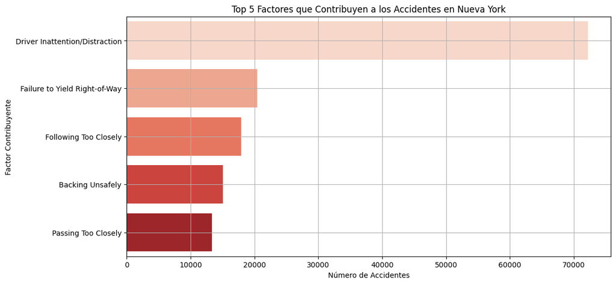

```python
# Nota de Eduardo: Agrege este gráfico

# Gráfica de los 10 principales factores
plt.figure(figsize=(12, 6))
sns.barplot(x=df_factores_group["count"][:5],
            y=df_factores_group["factores"][:5],
            hue=df_factores_group["factores"][:5],
            palette="Reds",
            legend=False)

# Etiquetas y título
plt.xlabel("Número de Accidentes")
plt.ylabel("Factor Contribuyente")
plt.title("Top 5 Factores que Contribuyen a los Accidentes en Nueva York")
plt.grid(True)

plt.show()
```

El top 5 de factores que provocan accidentes son:

1. Conductor distraido
2. No ceder el derecho al paso
3. Seguir demasiado de cerca de otro carro
4. Retroceder de forma insegura
5. Pasar muy cerca

### Ejercicio 8:

¿Qué tipos de vehículos están más involucrados en accidentes por municipio? Evite contar dos veces el tipo de vehículos presentes en un solo accidente.

**Sugerencia:** Puede aplicar un enfoque similar al utilizado en la pregunta anterior.

```
            BOROUGH                         Vehicle Type  count
181           BRONX                                Sedan  19652
185           BRONX  Station Wagon/Sport Utility Vehicle  15434
146           BRONX                    PASSENGER VEHICLE   4941
174           BRONX        SPORT UTILITY / STATION WAGON   3751
157           BRONX                        Pick-up Truck   1670
...             ...                                  ...    ...
1363  STATEN ISLAND                                 nyfd      1
1364  STATEN ISLAND                                sanit      1
1366  STATEN ISLAND                                truck      1
1368  STATEN ISLAND                                 usps      1
1369  STATEN ISLAND                                van t      1

[1370 rows x 3 columns]
```

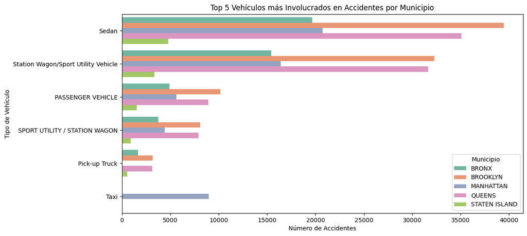

```python
# Definir las columnas de tipos de vehículos involucrados
vehiculo_col = ['VEHICLE TYPE CODE 1', 'VEHICLE TYPE CODE 2',
                'VEHICLE TYPE CODE 3', 'VEHICLE TYPE CODE 4',
                'VEHICLE TYPE CODE 5']

# Concatenar las columnas de vehículos junto con 'BOROUGH' y 'COLLISION_ID'
vehiculos = pd.concat([
    df_tim[['COLLISION_ID', 'BOROUGH', col]].rename(columns={col: "Vehicle Type"}) for col in vehiculo_col
])

# Resetear el índice después de la concatenación
vehiculos = vehiculos.reset_index(drop=True)

# Eliminar valores "Unknown" y duplicados dentro del mismo accidente
vehiculos = vehiculos[vehiculos["Vehicle Type"] != "Unknown"]
vehiculos = vehiculos.drop_duplicates(subset=['COLLISION_ID', 'Vehicle Type'])

# Agrupar
df_veh_group = vehiculos.groupby(['BOROUGH', "Vehicle Type"]).size().reset_index(name='count')
# Ordenar
df_veh_group = df_veh_group.sort_values(by=["BOROUGH", "count"], ascending=[True, False])


print(df_veh_group)

# Top de los involucrados en Accidentes por municipio
df_veh_top_5 = df_veh_group.sort_values(by=["BOROUGH", "count"], ascending=[True, False]).groupby("BOROUGH").head(5)

# Crear gráfico de barras agrupado por municipio
plt.figure(figsize=(12, 6))
sns.barplot(x="count", y="Vehicle Type", hue="BOROUGH", data=df_veh_top_5, palette="Set2")
plt.xlabel("Número de Accidentes")
plt.ylabel("Tipo de Vehículo")
plt.title("Top 5 Vehículos más Involucrados en Accidentes por Municipio")
plt.legend(title="Municipio")

plt.show()
```

### Ejercicio 9:

En 2018 para una [entrevista](https://www.nytimes.com/2019/01/01/nyregion/traffic-deaths-decrease-nyc.html) con The New York Times, el alcalde de Blasio de Nueva York declaró que *'Vision Zero está funcionando claramente'*. Ese año, el número de muertes en accidentes de tráfico en Nueva York se redujo a un histórico 202. Sin embargo, según lo informado por [am New York Metro](https://www.amny.com/news/vision-zero-de-blasio- 1-30707464 /), el número de víctimas mortales ha aumentado un 30% en el primer trimestre de 2019 en comparación con el año anterior y el número de peatones y ciclistas heridos no ha experimentado ninguna mejora.

¿Cómo utilizaría los datos proporcionados para comprender qué salió mal en el primer trimestre de 2019?

> - Considere los accidentes del primer trimestre de 2019. Luego, busque las causas más comunes de accidentes en los que estuvieron involucrados peatones y ciclistas. Dé una recomendación basada únicamente en esta información.
> - Cree un par de mapas de calor de los accidentes que involucraron a peatones y ciclistas lesionados / muertos en el primer trimestre de 2018 y 2019. Compare estos dos para ver si hay algún cambio en la concentración de accidentes. En áreas críticas, estudie el tipo de factores involucrados en los accidentes. Dé una recomendación para visitar estas áreas para estudiar más el problema.
> - Los datos proporcionados son insuficientes para mejorar nuestra comprensión de la situación.
> - Ninguna de las anteriores. Haría lo siguiente: *aquí tu respuesta recomendada*.

**La mejor opción es:**

Crear un par de mapas de calor de los accidentes que involucraron a peatones y ciclistas lesionados / muertos en el primer trimestre de 2018 y 2019. Compare estos dos para ver si hay algún cambio en la concentración de accidentes. En áreas críticas, estudie el tipo de factores involucrados en los accidentes. Dé una recomendación para visitar estas áreas para estudiar más el problema.

**Justificación:** La opción más completa no solo analiza las causas más comunes, sino que también compara los datos de dos períodos diferentes para identificar cambios en la concentración de accidentes. Además, propone un estudio más detallado en áreas críticas, lo que puede proporcionar información valiosa para implementar mejoras específicas. El análisis de mapas de calor y la evaluación en campo es la mejor estrategia para entender qué salió mal en el primer trimestre de 2019. Esto nos permitirá tomar decisiones más efectivas para reducir los accidentes en áreas críticas.

```python
import folium
from folium.plugins import HeatMap

df['DATE'] = pd.to_datetime(df['DATE'], format='%m/%d/%Y')

# Filtrar los datos del primer trimestre de 2018 y 2019
df_q1_2018 = df[(df['DATE'] >= '2018-01-01') & (df['DATE'] <= '2018-03-31')]
df_q1_2019 = df[(df['DATE'] >= '2019-01-01') & (df['DATE'] <= '2019-03-31')]

# Filtrar accidentes con peatones o ciclistas lesionados o muertos
df_q1_2018_ped_cyc = df_q1_2018[
    (df_q1_2018['NUMBER OF PEDESTRIANS INJURED'] > 0) |
    (df_q1_2018['NUMBER OF PEDESTRIANS KILLED'] > 0) |
    (df_q1_2018['NUMBER OF CYCLIST INJURED'] > 0) |
    (df_q1_2018['NUMBER OF CYCLIST KILLED'] > 0)
]

df_q1_2019_ped_cyc = df_q1_2019[
    (df_q1_2019['NUMBER OF PEDESTRIANS INJURED'] > 0) |
    (df_q1_2019['NUMBER OF PEDESTRIANS KILLED'] > 0) |
    (df_q1_2019['NUMBER OF CYCLIST INJURED'] > 0) |
    (df_q1_2019['NUMBER OF CYCLIST KILLED'] > 0)
]

# Crear un mapa de calor para el primer trimestre de 2018
m_2018 = folium.Map(location=[40.7128, -74.0060], zoom_start=11)
heat_data_2018 = list(zip(df_q1_2018_ped_cyc['LATITUDE'].dropna(), df_q1_2018_ped_cyc['LONGITUDE'].dropna()))
HeatMap(heat_data_2018).add_to(m_2018)

# Crear un mapa de calor para el primer trimestre de 2019
m_2019 = folium.Map(location=[40.7128, -74.0060], zoom_start=11)
heat_data_2019 = list(zip(df_q1_2019_ped_cyc['LATITUDE'].dropna(), df_q1_2019_ped_cyc['LONGITUDE'].dropna()))
HeatMap(heat_data_2019).add_to(m_2019)
```

```
<folium.plugins.heat_map.HeatMap at 0x7b6c001e1590>
```

```python
print("Mapa de Calor - Primer Trimestre 2018")
m_2018
```

```
Mapa de Calor - Primer Trimestre 2018
```

Make this Notebook Trusted to load map: File -> Trust Notebook

[interactive chart not shown]

```python
print("Mapa de Calor - Primer Trimestre 2019")
m_2019
```

```
Mapa de Calor - Primer Trimestre 2019
```

Make this Notebook Trusted to load map: File -> Trust Notebook

[interactive chart not shown]

En la comparación de los mapas de calor de accidentes con peatones y ciclistas lesionados o muertos en el primer trimestre de 2018 y 2019, se observa que la concentración de accidentes se mantiene en áreas similares, con alta densidad en Manhattan, Brooklyn y parte Queens. Sin embargo, en 2019, la zona de alta incidencia parece haberse expandido.

Ahora se va a estudiar el tipo de factores involucrados en los accidentes:

```
Factores más comunes en los accidentes de peatones y ciclistas en áreas críticas (Q1 2019):
                                              Factor  Count
0                     Driver Inattention/Distraction    583
1                                        Unspecified    552
2                      Failure to Yield Right-of-Way    487
3  Pedestrian/Bicyclist/Other Pedestrian Error/Co...     89
4                                   Backing Unsafely     63
```

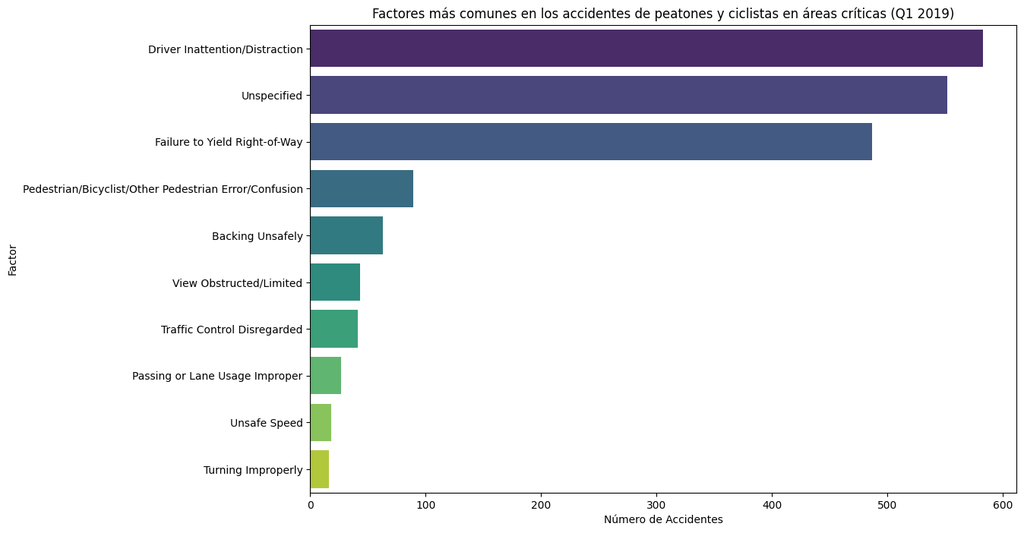

```python
# Filtrar los datos para el primer trimestre de 2019 en áreas críticas
critical_areas_q1_2019 = df[(df['BOROUGH'].isin(['MANHATTAN', 'BROOKLYN', 'QUEENS'])) &
                            (df['DATE'] >= '2019-01-01') & (df['DATE'] <= '2019-03-31') &
                            ((df['NUMBER OF PEDESTRIANS INJURED'] > 0) |
                             (df['NUMBER OF PEDESTRIANS KILLED'] > 0) |
                             (df['NUMBER OF CYCLIST INJURED'] > 0) |
                             (df['NUMBER OF CYCLIST KILLED'] > 0))]

# Analizar los factores involucrados en los accidentes en áreas críticas
factors = critical_areas_q1_2019['CONTRIBUTING FACTOR VEHICLE 1'].value_counts().reset_index()
factors.columns = ['Factor', 'Count']

# Mostrar los factores más comunes
print("Factores más comunes en los accidentes de peatones y ciclistas en áreas críticas (Q1 2019):")
print(factors.head(5))

# Visualizar los factores más comunes
plt.figure(figsize=(12, 8))
sns.barplot(x='Count', y='Factor', data=factors.head(10), hue='Factor', palette='viridis', legend=False)
plt.title('Factores más comunes en los accidentes de peatones y ciclistas en áreas críticas (Q1 2019)')
plt.xlabel('Número de Accidentes')
plt.ylabel('Factor')
plt.show()
```

**Recomendación:** Se recomienda realizar visitas de campo en Manhattan, Brooklyn y Queens para estudiar los factores más comunes de accidentes de peatones y ciclistas en el primer trimestre de 2019. Estas visitas deben enfocarse en monitorear la distracción de los conductores (583 casos) y la falta de ceder el paso (487 casos), revisar la señalización y visibilidad en cruces conflictivos, analizar problemas de prioridad de paso, y examinar zonas donde los vehículos retroceden de manera insegura (63 casos).

### Ejercicio 10:

Calcula el número de muertes provocadas por cada tipo de vehículo. Trace un gráfico de barras para los 5 vehículos principales. ¿Qué vehículos están involucrados con mayor frecuencia en las muertes y cuánto más que los demás?

**Por ejemplo,** si dos personas murieron en un accidente en el que estuvieron involucrados 5 vehículos: 4 son VEHÍCULOS DE PASAJEROS y 1 es un VAGÓN DEPORTIVO / ESTACIÓN. Luego, agregaríamos dos muertes a cada tipo de VEHÍCULO DE PASAJEROS y VAGÓN DE ESTACIÓN / SERVICIO DEPORTIVO.

**Sugerencia:** Es posible que desee crear una nueva columna con el número total de muertes en el accidente. Para eso, puede encontrar útil la función `.to_numpy()`. Luego, proceda como los ejercicios anteriores para evitar contabilizar dos veces el tipo de vehículos.

```python
# Crear columna con total de muertes
df_tim['Total Deaths'] = df_tim[['NUMBER OF CYCLIST KILLED', 'NUMBER OF MOTORIST KILLED', 'NUMBER OF PEDESTRIANS KILLED']].sum(axis=1)
# Nuevo dataframe con los datos necesarios
df_ve_mu = df_tim[['VEHICLE TYPE CODE 1', 'VEHICLE TYPE CODE 2', 'VEHICLE TYPE CODE 3', 'VEHICLE TYPE CODE 4', 'VEHICLE TYPE CODE 5', 'Total Deaths']]
# Crear ID para index
df_ve_mu['ID'] = df_ve_mu.index
# Nuevo dataframe con la data descompuesta
df_ve_mu_di = df_ve_mu.melt(id_vars=['ID','Total Deaths'], var_name='Vehicle', value_name='Deaths', value_vars=['VEHICLE TYPE CODE 1', 'VEHICLE TYPE CODE 2', 'VEHICLE TYPE CODE 3', 'VEHICLE TYPE CODE 4', 'VEHICLE TYPE CODE 5'])
print(df_ve_mu_di)
```

```
             ID  Total Deaths              Vehicle   Deaths
0             0             0  VEHICLE TYPE CODE 1    Sedan
1             1             0  VEHICLE TYPE CODE 1    Sedan
2             2             0  VEHICLE TYPE CODE 1    Sedan
3             3             0  VEHICLE TYPE CODE 1     Bike
4             4             0  VEHICLE TYPE CODE 1    Sedan
...         ...           ...                  ...      ...
1192605  238517             0  VEHICLE TYPE CODE 5  Unknown
1192606  238518             0  VEHICLE TYPE CODE 5  Unknown
1192607  238519             0  VEHICLE TYPE CODE 5  Unknown
1192608  238520             0  VEHICLE TYPE CODE 5  Unknown
1192609  238521             0  VEHICLE TYPE CODE 5  Unknown

[1192610 rows x 4 columns]
```

```python
df_ve_mu_di.groupby('Deaths')['Total Deaths'].sum().reset_index(name='count').sort_values(by='count', ascending=False)
```

|  | Deaths | count |
| --- | --- | --- |
| 476 | Unknown | 748 |
| 405 | Station Wagon/Sport Utility Vehicle | 100 |
| 395 | Sedan | 79 |
| 318 | PASSENGER VEHICLE | 33 |
| 381 | SPORT UTILITY / STATION WAGON | 26 |
| ... | ... | ... |
| 220 | HINO | 0 |
| 221 | HO | 0 |
| 222 | HORSE | 0 |
| 223 | HOTDO | 0 |
| 647 | ï¿½MBU | 0 |

648 rows × 2 columns

```python
df_deaths = df_ve_mu_di.groupby('Deaths')['Total Deaths'].sum().reset_index(name='count').sort_values(by='count', ascending=False).head(6)
print(df_deaths)
```

```
                                  Deaths  count
476                              Unknown    748
405  Station Wagon/Sport Utility Vehicle    100
395                                Sedan     79
318                    PASSENGER VEHICLE     33
381        SPORT UTILITY / STATION WAGON     26
289                           Motorcycle     22
```

[figure not shown]

```python
# grafica de barras por dia de la semana
fig, ax = plt.subplots(figsize=(12, 5))

ax.bar(df_deaths['Deaths'], df_deaths['count'])

# Rotar etiquetas para evitar superposiciones
plt.xticks(rotation=45, ha='right')

# Etiquetar ejes y titulo
plt.title('Top 5 Vehiculos por número de muertes')
plt.xlabel('Vehiculos')
plt.ylabel('Muertes')
plt.show()
```

**RESPUESTA:** El gráfico de barras muestra los 5 tipos de vehículos más involucrados en muertes. La categoría "Unknown" encabeza la lista, lo que indica una alta cantidad de registros sin especificar, afectando la precisión del análisis. Entre los vehículos identificados, los "Station Wagon/SUV" y "Sedan" presentan el mayor número de muertes, superando significativamente a otros tipos. Por otro lado, los "Passenger Vehicle", "Sport Utility/Station Wagon" y "Motorcycle" tienen una menor incidencia, aunque siguen siendo relevantes. La diferencia es notable, ya que los Station Wagon/SUV y Sedanes tienen aproximadamente el doble o más muertes que otros vehículos, lo que sugiere que su frecuencia en las calles o ciertas características pueden aumentar el riesgo de accidentes fatales